# Simulating the False Positive Rate due to common practices in the analysis of IRAP research

### Run simulations

```r
# sure directly exists
dir.create("results")

set.seed(42)

# long runtime, so save to disk and reload if possible
if(!file.exists("results/simulation_results_genericpattern.rds")){

  # data generation
  simulated_data_genericpattern <-
    bind_rows(
      # true null population effects
      generate_data(n_iterations   = n_iterations,
                    n_participants = 20),
      generate_data(n_iterations   = n_iterations,
                    n_participants = 40),
      generate_data(n_iterations   = n_iterations,
                    n_participants = 60),
      generate_data(n_iterations   = n_iterations,
                    n_participants = 80),
      generate_data(n_iterations   = n_iterations,
                    n_participants = 500),
      # generic pattern population effects
      generate_data(n_iterations   = n_iterations,
                    n_participants = 20,
                    means          = means_and_sds$weighted_mean_mean,
                    sds            = means_and_sds$weighted_mean_sd,
                    r              = correlations_matrix),
      generate_data(n_iterations   = n_iterations,
                    n_participants = 40,
                    means          = means_and_sds$weighted_mean_mean,
                    sds            = means_and_sds$weighted_mean_sd,
                    r              = correlations_matrix),
      generate_data(n_iterations   = n_iterations,
                    n_participants = 60,
                    means          = means_and_sds$weighted_mean_mean,
                    sds            = means_and_sds$weighted_mean_sd,
                    r              = correlations_matrix),
      generate_data(n_iterations   = n_iterations,
                    n_participants = 80,
                    means          = means_and_sds$weighted_mean_mean,
                    sds            = means_and_sds$weighted_mean_sd,
                    r              = correlations_matrix),
      generate_data(n_iterations   = n_iterations,
                    n_participants = 500,
                    means          = means_and_sds$weighted_mean_mean,
                    sds            = means_and_sds$weighted_mean_sd,
                    r              = correlations_matrix),
    ) |>
    # ez::ezANOVA converts from tbl_df to data frame. to speed up sims, do this once here
    as.data.frame()


  # fit analyses to data
  simulation_results_genericpattern <- simulated_data_genericpattern |>
    mutate(
      results_rmanova_4trialtypes_maineffecttt =
        future_map(data,
                   analysis_rmanova_4trialtypes_maineffecttt,
                   .progress = TRUE,
                   .options = furrr_options(seed = TRUE)) |>
        as.logical()
    )

  write_rds(simulation_results_genericpattern, "results/simulation_results_genericpattern.rds", compress = "gz")

} else {
  simulation_results_genericpattern <- read_rds("results/simulation_results_genericpattern.rds")
}


# create joint decisions based on combinations of individual analyses
# calculate FPR for different combinations of analyses
simulation_results_genericpattern_fpr <- simulation_results_genericpattern |>
  dplyr::select(-iteration, -data) |>
  rowwise() |>
  mutate(
    simulation_0 = as.logical(results_rmanova_4trialtypes_maineffecttt)
  ) |>
  ungroup() |>
  pivot_longer(cols = c(-n_participants, -means, -sds, -r),
               names_to = "analysis",
               values_to = "result") |>
  group_by(n_participants, means, sds, r, analysis) |>
  summarize(fpr_estimate = mean(result),
            fpr_se = plotrix::std.error(result),
            fpr_ci_lower = fpr_estimate - fpr_se*1.96,
            fpr_ci_upper = fpr_estimate + fpr_se*1.96)

write_csv(simulation_results_genericpattern_fpr, "results/simulation_results_genericpattern_fpr.csv")
# simulation_results_genericpattern_fpr <- read_csv("results/simulation_results_genericpattern_fpr.csv")
```

### Inspect individual simulation results and Monte Carlo errors

```r
simulation_results_genericpattern_fpr |>
  round_df(2) |>
  kable() |>
  kable_styling(bootstrap_options = c("striped", "hover", "condensed"), full_width = FALSE)
```

| n_participants | means | sds | r | analysis | fpr_estimate | fpr_se | fpr_ci_lower | fpr_ci_upper |
| --- | --- | --- | --- | --- | --- | --- | --- | --- |
| 20 | 0, 0, 0, 0 | 1, 1, 1, 1 | 0 | results_rmanova_4trialtypes_maineffecttt | 0.05 | 0.01 | 0.04 | 0.06 |
| 20 | 0, 0, 0, 0 | 1, 1, 1, 1 | 0 | simulation_0 | 0.05 | 0.01 | 0.04 | 0.06 |
| 20 | 0.36, 0.15, -0.18, 0.02 | 0.36, 0.38, 0.38, 0.38 | 1, 0.15, 0.13, 0.17, 0.15, 1, 0.11, 0.07, 0.13, 0.11, 1, 0.22, 0.17, 0.07, 0.22, 1 | results_rmanova_4trialtypes_maineffecttt | 0.99 | 0.00 | 0.99 | 1.00 |
| 20 | 0.36, 0.15, -0.18, 0.02 | 0.36, 0.38, 0.38, 0.38 | 1, 0.15, 0.13, 0.17, 0.15, 1, 0.11, 0.07, 0.13, 0.11, 1, 0.22, 0.17, 0.07, 0.22, 1 | simulation_0 | 0.99 | 0.00 | 0.99 | 1.00 |
| 40 | 0, 0, 0, 0 | 1, 1, 1, 1 | 0 | results_rmanova_4trialtypes_maineffecttt | 0.05 | 0.01 | 0.04 | 0.07 |
| 40 | 0, 0, 0, 0 | 1, 1, 1, 1 | 0 | simulation_0 | 0.05 | 0.01 | 0.04 | 0.07 |
| 40 | 0.36, 0.15, -0.18, 0.02 | 0.36, 0.38, 0.38, 0.38 | 1, 0.15, 0.13, 0.17, 0.15, 1, 0.11, 0.07, 0.13, 0.11, 1, 0.22, 0.17, 0.07, 0.22, 1 | results_rmanova_4trialtypes_maineffecttt | 1.00 | 0.00 | 1.00 | 1.00 |
| 40 | 0.36, 0.15, -0.18, 0.02 | 0.36, 0.38, 0.38, 0.38 | 1, 0.15, 0.13, 0.17, 0.15, 1, 0.11, 0.07, 0.13, 0.11, 1, 0.22, 0.17, 0.07, 0.22, 1 | simulation_0 | 1.00 | 0.00 | 1.00 | 1.00 |
| 60 | 0, 0, 0, 0 | 1, 1, 1, 1 | 0 | results_rmanova_4trialtypes_maineffecttt | 0.05 | 0.01 | 0.04 | 0.07 |
| 60 | 0, 0, 0, 0 | 1, 1, 1, 1 | 0 | simulation_0 | 0.05 | 0.01 | 0.04 | 0.07 |
| 60 | 0.36, 0.15, -0.18, 0.02 | 0.36, 0.38, 0.38, 0.38 | 1, 0.15, 0.13, 0.17, 0.15, 1, 0.11, 0.07, 0.13, 0.11, 1, 0.22, 0.17, 0.07, 0.22, 1 | results_rmanova_4trialtypes_maineffecttt | 1.00 | 0.00 | 1.00 | 1.00 |
| 60 | 0.36, 0.15, -0.18, 0.02 | 0.36, 0.38, 0.38, 0.38 | 1, 0.15, 0.13, 0.17, 0.15, 1, 0.11, 0.07, 0.13, 0.11, 1, 0.22, 0.17, 0.07, 0.22, 1 | simulation_0 | 1.00 | 0.00 | 1.00 | 1.00 |
| 80 | 0, 0, 0, 0 | 1, 1, 1, 1 | 0 | results_rmanova_4trialtypes_maineffecttt | 0.04 | 0.01 | 0.03 | 0.06 |
| 80 | 0, 0, 0, 0 | 1, 1, 1, 1 | 0 | simulation_0 | 0.04 | 0.01 | 0.03 | 0.06 |
| 80 | 0.36, 0.15, -0.18, 0.02 | 0.36, 0.38, 0.38, 0.38 | 1, 0.15, 0.13, 0.17, 0.15, 1, 0.11, 0.07, 0.13, 0.11, 1, 0.22, 0.17, 0.07, 0.22, 1 | results_rmanova_4trialtypes_maineffecttt | 1.00 | 0.00 | 1.00 | 1.00 |
| 80 | 0.36, 0.15, -0.18, 0.02 | 0.36, 0.38, 0.38, 0.38 | 1, 0.15, 0.13, 0.17, 0.15, 1, 0.11, 0.07, 0.13, 0.11, 1, 0.22, 0.17, 0.07, 0.22, 1 | simulation_0 | 1.00 | 0.00 | 1.00 | 1.00 |
| 500 | 0, 0, 0, 0 | 1, 1, 1, 1 | 0 | results_rmanova_4trialtypes_maineffecttt | 0.05 | 0.01 | 0.04 | 0.06 |
| 500 | 0, 0, 0, 0 | 1, 1, 1, 1 | 0 | simulation_0 | 0.05 | 0.01 | 0.04 | 0.06 |
| 500 | 0.36, 0.15, -0.18, 0.02 | 0.36, 0.38, 0.38, 0.38 | 1, 0.15, 0.13, 0.17, 0.15, 1, 0.11, 0.07, 0.13, 0.11, 1, 0.22, 0.17, 0.07, 0.22, 1 | results_rmanova_4trialtypes_maineffecttt | 1.00 | 0.00 | 1.00 | 1.00 |
| 500 | 0.36, 0.15, -0.18, 0.02 | 0.36, 0.38, 0.38, 0.38 | 1, 0.15, 0.13, 0.17, 0.15, 1, 0.11, 0.07, 0.13, 0.11, 1, 0.22, 0.17, 0.07, 0.22, 1 | simulation_0 | 1.00 | 0.00 | 1.00 | 1.00 |

### Summarize results

```r
# summary table
simulation_results_genericpattern_fpr_table <- simulation_results_genericpattern_fpr |>
  select(-fpr_se,
         -fpr_ci_lower,
         -fpr_ci_upper) |>
  pivot_wider(names_from = analysis,
              values_from = fpr_estimate)

simulation_results_genericpattern_fpr_table |>
  select(n_participants, means, sds, r,
         simulation_0) |>
  kable() |>
  kable_styling(bootstrap_options = c("striped", "hover", "condensed"), full_width = FALSE)
```

| n_participants | means | sds | r | simulation_0 |
| --- | --- | --- | --- | --- |
| 20 | 0, 0, 0, 0 | 1, 1, 1, 1 | 0 | 0.051 |
| 20 | 0.36, 0.15, -0.18, 0.02 | 0.36, 0.38, 0.38, 0.38 | 1, 0.15, 0.13, 0.17, 0.15, 1, 0.11, 0.07, 0.13, 0.11, 1, 0.22, 0.17, 0.07, 0.22, 1 | 0.992 |
| 40 | 0, 0, 0, 0 | 1, 1, 1, 1 | 0 | 0.054 |
| 40 | 0.36, 0.15, -0.18, 0.02 | 0.36, 0.38, 0.38, 0.38 | 1, 0.15, 0.13, 0.17, 0.15, 1, 0.11, 0.07, 0.13, 0.11, 1, 0.22, 0.17, 0.07, 0.22, 1 | 1.000 |
| 60 | 0, 0, 0, 0 | 1, 1, 1, 1 | 0 | 0.053 |
| 60 | 0.36, 0.15, -0.18, 0.02 | 0.36, 0.38, 0.38, 0.38 | 1, 0.15, 0.13, 0.17, 0.15, 1, 0.11, 0.07, 0.13, 0.11, 1, 0.22, 0.17, 0.07, 0.22, 1 | 1.000 |
| 80 | 0, 0, 0, 0 | 1, 1, 1, 1 | 0 | 0.044 |
| 80 | 0.36, 0.15, -0.18, 0.02 | 0.36, 0.38, 0.38, 0.38 | 1, 0.15, 0.13, 0.17, 0.15, 1, 0.11, 0.07, 0.13, 0.11, 1, 0.22, 0.17, 0.07, 0.22, 1 | 1.000 |
| 500 | 0, 0, 0, 0 | 1, 1, 1, 1 | 0 | 0.049 |
| 500 | 0.36, 0.15, -0.18, 0.02 | 0.36, 0.38, 0.38, 0.38 | 1, 0.15, 0.13, 0.17, 0.15, 1, 0.11, 0.07, 0.13, 0.11, 1, 0.22, 0.17, 0.07, 0.22, 1 | 1.000 |

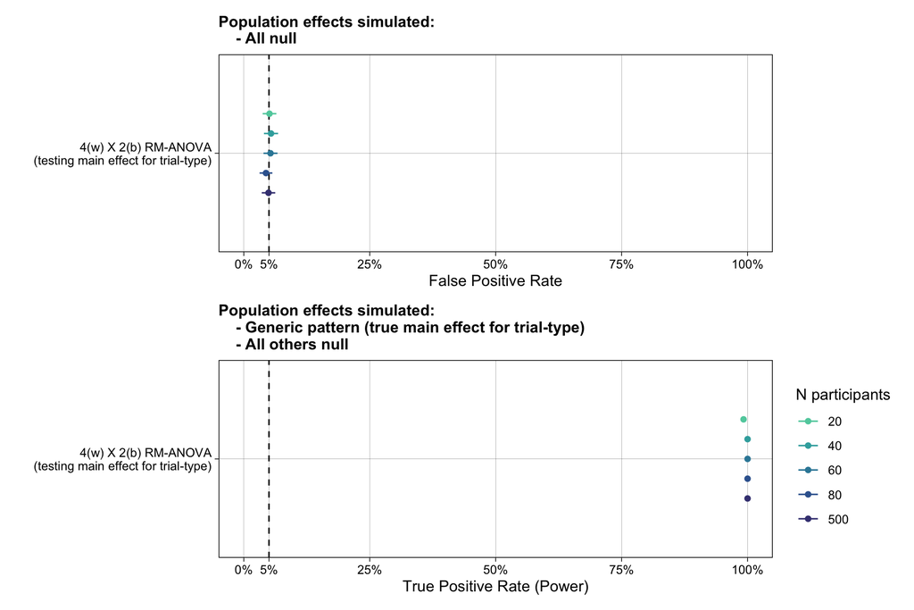

```r
# summary plot of simulation results
simulation_results_genericpattern_fpr_plot <- simulation_results_genericpattern_fpr |>
  filter(analysis %in% c("simulation_0")) |>
  mutate(n_participants = as.factor(n_participants),
         n_participants = fct_rev(n_participants),
         analysis = dplyr::case_match(analysis,
                                      "simulation_0" ~ "4(w) X 2(b) RM-ANOVA\n(testing main effect for trial-type)"),
         analysis = fct_rev(analysis))

p1a <- simulation_results_genericpattern_fpr_plot |>
  filter(means == c("0, 0, 0, 0")) |>
  ggplot(aes(fpr_estimate, analysis, color = n_participants)) +
  geom_vline(xintercept = 0.05, linetype = "dashed") +
  geom_linerangeh(aes(xmin = fpr_ci_lower, xmax = fpr_ci_upper), position = position_dodge(width = 0.6)) +
  geom_point(position = position_dodge(width = 0.6)) +
  scale_color_viridis_d(begin = 0.3, end = 0.8, option = "mako", guide = guide_legend(reverse=TRUE)) +
  theme_linedraw() +
  xlab("False Positive Rate") +
  ylab("") +
  labs(color = "N participants") +
  scale_x_continuous(labels = scales::percent_format(scale = 100), breaks = c(0.00, .05, .25, .50, .75, 1.00)) +
  coord_cartesian(xlim = c(0, 1)) +
  theme(panel.grid.minor = element_blank(),
        plot.title = element_text(size = 11, face = "bold"),
        legend.position = "none") +
  ggtitle("Population effects simulated:\n    - All null")

p1b <- simulation_results_genericpattern_fpr_plot |>
  filter(means != c("0, 0, 0, 0")) |>
  ggplot(aes(fpr_estimate, analysis, color = n_participants)) +
  geom_vline(xintercept = 0.05, linetype = "dashed") +
  geom_linerangeh(aes(xmin = fpr_ci_lower, xmax = fpr_ci_upper), position = position_dodge(width = 0.6)) +
  geom_point(position = position_dodge(width = 0.6)) +
  scale_color_viridis_d(begin = 0.3, end = 0.8, option = "mako", guide = guide_legend(reverse=TRUE)) +
  theme_linedraw() +
  xlab("True Positive Rate (Power)") +
  ylab("") +
  labs(color = "N participants") +
  scale_x_continuous(labels = scales::percent_format(scale = 100), breaks = c(0.00, .05, .25, .50, .75, 1.00)) +
  coord_cartesian(xlim = c(0, 1)) +
  theme(panel.grid.minor = element_blank(),
        plot.title = element_text(size = 11, face = "bold")) +
  ggtitle("Population effects simulated:\n    - Generic pattern (true main effect for trial-type)\n    - All others null")


library(patchwork)
p1 <- p1a + p1b + plot_layout(ncol = 1)

p1
```

```r
dir.create("../plots/")

ggsave("../plots/p1.pdf",
       plot = p1,
       device = "pdf",
       width = 9,
       height = 4,
       units = "in")
```

## All population effects are null/zero

### Run simulations

```r
# sure directly exists
dir.create("results")

set.seed(42)

# long run time, so save to disk and reload if possible
if(!file.exists("results/simulation_results_null.rds")){

  # data generation
  simulated_data_null <-
    bind_rows(
      generate_data(n_iterations   = n_iterations,
                    n_participants = 20),
      generate_data(n_iterations   = n_iterations,
                    n_participants = 40),
      generate_data(n_iterations   = n_iterations,
                    n_participants = 60),
      generate_data(n_iterations   = n_iterations,
                    n_participants = 80),
      generate_data(n_iterations   = n_iterations,
                    n_participants = 500)
    ) |>
    # ez::ezANOVA converts from tbl_df to data frame. to speed up sims, do this once here
    as.data.frame()


  # fit analyses to data
  simulation_results_null <- simulated_data_null |>
    mutate(
      results_rmanova_4trialtypes =
        future_map(data,
                   analysis_rmanova_4trialtypes,
                   .progress = TRUE,
                   .options = furrr_options(seed = TRUE)) |>
        as.logical(),

      results_indepttests_4trialtypes =
        future_map(data,
                   analysis_indepttests_4trialtypes,
                   .progress = TRUE,
                   .options = furrr_options(seed = TRUE)) |>
        as.logical(),

      results_onesampttests_4trialtypes =
        future_map(data,
                   analysis_onesampttests_4trialtypes,
                   .progress = TRUE,
                   .options = furrr_options(seed = TRUE)) |>
        as.logical(),

      results_indepttests_1trialtype =
        future_map(data,
                   analysis_indepttests_1trialtype,
                   .progress = TRUE,
                   .options = furrr_options(seed = TRUE)) |>
        as.logical(),

      results_onesampttests_1trialtype =
        future_map(data,
                   analysis_onesampttests_1trialtype,
                   .progress = TRUE,
                   .options = furrr_options(seed = TRUE)) |>
        as.logical(),

      results_rmanova_4trialtypes_blockorder =
        future_map(data,
                   analysis_rmanova_4trialtypes_blockorder,
                   .progress = TRUE,
                   .options = furrr_options(seed = TRUE)) |>
        as.logical(),

      results_indepttests_4trialtypes_blockorder =
        future_map(data,
                   analysis_indepttests_4trialtypes_blockorder,
                   .progress = TRUE,
                   .options = furrr_options(seed = TRUE)) |>
        as.logical(),

      results_onesampttests_4trialtypes_blockorder =
        future_map(data,
                   analysis_onesampttests_4trialtypes_blockorder,
                   .progress = TRUE,
                   .options = furrr_options(seed = TRUE)) |>
        as.logical()
    )

  write_rds(simulation_results_null, "results/simulation_results_null.rds", compress = "gz")

} else {
  simulation_results_null <- read_rds("results/simulation_results_null.rds")
}

# create joint decisions based on combinations of individual analyses
# calculate FPR for different combinations of analyses
simulation_results_null_fpr <- simulation_results_null |>
  dplyr::select(-iteration, -data) |>
  rowwise() |>
  mutate(
    # 4 trial-types, between groups, with increasing followup tests
    simulation_1 = as.logical(results_rmanova_4trialtypes),
    simulation_2 = as.logical(max(results_rmanova_4trialtypes,
                                  results_indepttests_4trialtypes)),
    simulation_3 = as.logical(max(results_rmanova_4trialtypes,
                                  results_indepttests_4trialtypes,
                                  results_onesampttests_4trialtypes)),

    # sims 4-6 dropped as they simulated situations no longer commonly encountered

    # 1 D score, between groups, with increasing followup tests
    simulation_7 = as.logical(results_indepttests_1trialtype),
    simulation_8 = as.logical(max(results_indepttests_1trialtype,
                                  results_onesampttests_1trialtype)),

    # 4 trial-types, between groups and additional covariate, no followup tests b/c too many permutations
    simulation_9  = as.logical(results_rmanova_4trialtypes_blockorder),
    simulation_10 = as.logical(max(results_rmanova_4trialtypes_blockorder,
                                   results_indepttests_4trialtypes_blockorder)),
    simulation_11 = as.logical(max(results_rmanova_4trialtypes_blockorder,
                                   results_indepttests_4trialtypes_blockorder,
                                   results_onesampttests_4trialtypes_blockorder))
  ) |>
  mutate(
    # EDoF: optionally collapsing trial-types
    simulation_12 = as.logical(max(simulation_1,
                                   simulation_7)), # no followups

    # EDoF: optionally collapsing trial-types & followup tests
    simulation_13 = as.logical(max(simulation_2,
                                   simulation_7)), # between groups ttests
    simulation_14 = as.logical(max(simulation_3,
                                   simulation_8)), # between groups and diff from zero ttests

    # EDoF: optional additional covariate
    simulation_15 = as.logical(max(simulation_1, simulation_9)),
    # followup tests + EDoF: optional additional covariate
    simulation_16 = as.logical(max(simulation_2, simulation_10)),
    # followup tests and diff from zero tests + EDoF: optional additional covariate
    simulation_17 = as.logical(max(simulation_3, simulation_11)),
    # followup tests and diff from zero tests + EDoF: in EITHER covariate or collapsing tts
    simulation_18 = as.logical(max(simulation_3,
                                   simulation_8,
                                   simulation_11))
  ) |>
  ungroup() |>
  pivot_longer(cols = c(-n_participants, -means, -sds, -r),
               names_to = "analysis",
               values_to = "result") |>
  group_by(n_participants, means, sds, r, analysis) |>
  summarize(fpr_estimate = mean(result),
            fpr_se = plotrix::std.error(result),
            fpr_ci_lower = fpr_estimate - fpr_se*1.96,
            fpr_ci_upper = fpr_estimate + fpr_se*1.96)

write_csv(simulation_results_null_fpr, "results/simulation_results_null_fpr.csv")
# simulation_results_null_fpr <- read_csv("results/simulation_results_null_fpr.csv")
```

### Inspect individual simulation results and Monte Carlo errors

```r
simulation_results_null_fpr |>
  round_df(2) |>
  kable() |>
  kable_styling(bootstrap_options = c("striped", "hover", "condensed"), full_width = FALSE)
```

| n_participants | means | sds | r | analysis | fpr_estimate | fpr_se | fpr_ci_lower | fpr_ci_upper |
| --- | --- | --- | --- | --- | --- | --- | --- | --- |
| 20 | 0, 0, 0, 0 | 1, 1, 1, 1 | 0 | results_indepttests_1trialtype | 0.05 | 0.01 | 0.03 | 0.06 |
| 20 | 0, 0, 0, 0 | 1, 1, 1, 1 | 0 | results_indepttests_4trialtypes | 0.20 | 0.01 | 0.18 | 0.22 |
| 20 | 0, 0, 0, 0 | 1, 1, 1, 1 | 0 | results_indepttests_4trialtypes_blockorder | 0.34 | 0.02 | 0.31 | 0.37 |
| 20 | 0, 0, 0, 0 | 1, 1, 1, 1 | 0 | results_onesampttests_1trialtype | 0.11 | 0.01 | 0.09 | 0.12 |
| 20 | 0, 0, 0, 0 | 1, 1, 1, 1 | 0 | results_onesampttests_4trialtypes | 0.33 | 0.01 | 0.30 | 0.36 |
| 20 | 0, 0, 0, 0 | 1, 1, 1, 1 | 0 | results_onesampttests_4trialtypes_blockorder | 0.56 | 0.02 | 0.53 | 0.59 |
| 20 | 0, 0, 0, 0 | 1, 1, 1, 1 | 0 | results_rmanova_4trialtypes | 0.15 | 0.01 | 0.12 | 0.17 |
| 20 | 0, 0, 0, 0 | 1, 1, 1, 1 | 0 | results_rmanova_4trialtypes_blockorder | 0.30 | 0.01 | 0.27 | 0.33 |
| 20 | 0, 0, 0, 0 | 1, 1, 1, 1 | 0 | simulation_1 | 0.15 | 0.01 | 0.12 | 0.17 |
| 20 | 0, 0, 0, 0 | 1, 1, 1, 1 | 0 | simulation_10 | 0.48 | 0.02 | 0.45 | 0.51 |
| 20 | 0, 0, 0, 0 | 1, 1, 1, 1 | 0 | simulation_11 | 0.68 | 0.01 | 0.65 | 0.71 |
| 20 | 0, 0, 0, 0 | 1, 1, 1, 1 | 0 | simulation_12 | 0.15 | 0.01 | 0.12 | 0.17 |
| 20 | 0, 0, 0, 0 | 1, 1, 1, 1 | 0 | simulation_13 | 0.27 | 0.01 | 0.24 | 0.30 |
| 20 | 0, 0, 0, 0 | 1, 1, 1, 1 | 0 | simulation_14 | 0.45 | 0.02 | 0.42 | 0.48 |
| 20 | 0, 0, 0, 0 | 1, 1, 1, 1 | 0 | simulation_15 | 0.31 | 0.01 | 0.28 | 0.34 |
| 20 | 0, 0, 0, 0 | 1, 1, 1, 1 | 0 | simulation_16 | 0.54 | 0.02 | 0.50 | 0.57 |
| 20 | 0, 0, 0, 0 | 1, 1, 1, 1 | 0 | simulation_17 | 0.75 | 0.01 | 0.72 | 0.77 |
| 20 | 0, 0, 0, 0 | 1, 1, 1, 1 | 0 | simulation_18 | 0.76 | 0.01 | 0.73 | 0.78 |
| 20 | 0, 0, 0, 0 | 1, 1, 1, 1 | 0 | simulation_2 | 0.27 | 0.01 | 0.24 | 0.30 |
| 20 | 0, 0, 0, 0 | 1, 1, 1, 1 | 0 | simulation_3 | 0.43 | 0.02 | 0.40 | 0.46 |
| 20 | 0, 0, 0, 0 | 1, 1, 1, 1 | 0 | simulation_7 | 0.05 | 0.01 | 0.03 | 0.06 |
| 20 | 0, 0, 0, 0 | 1, 1, 1, 1 | 0 | simulation_8 | 0.12 | 0.01 | 0.10 | 0.14 |
| 20 | 0, 0, 0, 0 | 1, 1, 1, 1 | 0 | simulation_9 | 0.30 | 0.01 | 0.27 | 0.33 |
| 40 | 0, 0, 0, 0 | 1, 1, 1, 1 | 0 | results_indepttests_1trialtype | 0.05 | 0.01 | 0.04 | 0.06 |
| 40 | 0, 0, 0, 0 | 1, 1, 1, 1 | 0 | results_indepttests_4trialtypes | 0.20 | 0.01 | 0.17 | 0.22 |
| 40 | 0, 0, 0, 0 | 1, 1, 1, 1 | 0 | results_indepttests_4trialtypes_blockorder | 0.34 | 0.02 | 0.31 | 0.37 |
| 40 | 0, 0, 0, 0 | 1, 1, 1, 1 | 0 | results_onesampttests_1trialtype | 0.11 | 0.01 | 0.09 | 0.12 |
| 40 | 0, 0, 0, 0 | 1, 1, 1, 1 | 0 | results_onesampttests_4trialtypes | 0.35 | 0.02 | 0.32 | 0.38 |
| 40 | 0, 0, 0, 0 | 1, 1, 1, 1 | 0 | results_onesampttests_4trialtypes_blockorder | 0.57 | 0.02 | 0.54 | 0.60 |
| 40 | 0, 0, 0, 0 | 1, 1, 1, 1 | 0 | results_rmanova_4trialtypes | 0.16 | 0.01 | 0.14 | 0.19 |

[output cut: 85 more lines]

### Summarize results

Representing gradually worsening alpha control and then p hacking.

```r
# summary table of analytic strategies
tibble(analysis = c("Analytic strategy 1",
                    "Analytic strategy 2",
                    "Analytic strategy 3",
                    "Analytic strategy 4",
                    "Analytic strategy 5",
                    "Analytic strategy 6"),
       description = c("Base analysis: 4 (within: trial-type) X 2 (between: group) RM-ANOVA",
                       "+ Alpha inflation (also run follow-up between groups t-tests, without alpha control)",
                       "+ More alpha inflation (also run one-sample t-tests to assess differences from zero, without alpha control)",
                       "+ Analytic flexibility & selective reporting A (data processing: scoring data as one trial-type or four)",
                       "+ Analytic flexibility & selective reporting B (analysis: optionally including block-order as a covariate)",
                       "+ Analytic flexibility & selective reporting A & B (scoring & covariate)")) |>
  kable() |>
  kable_styling(bootstrap_options = c("striped", "hover", "condensed"), full_width = FALSE)
```

analysis

description

Analytic strategy 1

Base analysis: 4 (within: trial-type) X 2 (between: group) RM-ANOVA

Analytic strategy 2

- Alpha inflation (also run follow-up between groups t-tests, without alpha control)

Analytic strategy 3

- More alpha inflation (also run one-sample t-tests to assess differences from zero, without alpha control)

Analytic strategy 4

- Analytic flexibility & selective reporting A (data processing: scoring data as one trial-type or four)

Analytic strategy 5

- Analytic flexibility & selective reporting B (analysis: optionally including block-order as a covariate)

Analytic strategy 6

- Analytic flexibility & selective reporting A & B (scoring & covariate)

```r
# summary table
simulation_results_null_fpr_table <- simulation_results_null_fpr |>
  select(-fpr_se,
         -fpr_ci_lower,
         -fpr_ci_upper) |>
  pivot_wider(names_from = analysis,
              values_from = fpr_estimate) |>
  select(n_participants, means, sds, r,
         analytic_strategy_1 = simulation_1,
         analytic_strategy_2 = simulation_2,
         analytic_strategy_3 = simulation_3,
         analytic_strategy_4 = simulation_14,
         analytic_strategy_5 = simulation_17,
         analytic_strategy_6 = simulation_18)

simulation_results_null_fpr_table |>
  kable() |>
  kable_styling(bootstrap_options = c("striped", "hover", "condensed"), full_width = FALSE)
```

| n_participants | means | sds | r | analytic_strategy_1 | analytic_strategy_2 | analytic_strategy_3 | analytic_strategy_4 | analytic_strategy_5 | analytic_strategy_6 |
| --- | --- | --- | --- | --- | --- | --- | --- | --- | --- |
| 20 | 0, 0, 0, 0 | 1, 1, 1, 1 | 0 | 0.146 | 0.269 | 0.426 | 0.454 | 0.747 | 0.755 |
| 40 | 0, 0, 0, 0 | 1, 1, 1, 1 | 0 | 0.163 | 0.262 | 0.426 | 0.460 | 0.742 | 0.751 |
| 60 | 0, 0, 0, 0 | 1, 1, 1, 1 | 0 | 0.122 | 0.222 | 0.369 | 0.395 | 0.688 | 0.700 |
| 80 | 0, 0, 0, 0 | 1, 1, 1, 1 | 0 | 0.143 | 0.236 | 0.379 | 0.396 | 0.696 | 0.701 |
| 500 | 0, 0, 0, 0 | 1, 1, 1, 1 | 0 | 0.130 | 0.226 | 0.391 | 0.406 | 0.703 | 0.707 |

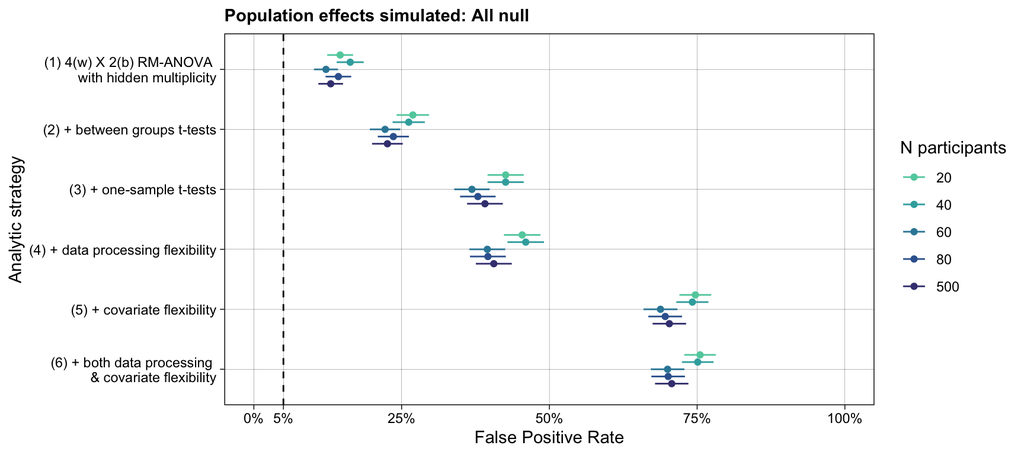

```r
# summary plot of simulation results
simulation_results_null_fpr_plot <- simulation_results_null_fpr |>
  filter(analysis %in% c("simulation_1", "simulation_2", "simulation_3",
                         "simulation_14", "simulation_17", "simulation_18")) |>
  mutate(n_participants = as.factor(n_participants),
         n_participants = fct_rev(n_participants),
         analysis = dplyr::case_match(analysis,
                                      "simulation_1" ~ "(1) 4(w) X 2(b) RM-ANOVA \nwith hidden multiplicity",
                                      "simulation_2" ~ "(2) + between groups t-tests",
                                      "simulation_3" ~ "(3) + one-sample t-tests",
                                      "simulation_14" ~ "(4) + data processing flexibility",
                                      "simulation_17" ~ "(5) + covariate flexibility",
                                      "simulation_18" ~ "(6) + both data processing \n& covariate flexibility"),
         analysis = fct_rev(analysis))

p2 <- ggplot(simulation_results_null_fpr_plot, aes(fpr_estimate, analysis, color = n_participants)) +
  geom_vline(xintercept = 0.05, linetype = "dashed") +
  geom_linerangeh(aes(xmin = fpr_ci_lower, xmax = fpr_ci_upper), position = position_dodge(width = 0.6)) +
  geom_point(position = position_dodge(width = 0.6)) +
  scale_color_viridis_d(begin = 0.3, end = 0.8, option = "mako", guide = guide_legend(reverse=TRUE)) +
  theme_linedraw() +
  xlab("False Positive Rate") +
  ylab("Analytic strategy") +
  labs(color = "N participants") +
  scale_x_continuous(labels = scales::percent_format(scale = 100), breaks = c(0.00, .05, .25, .50, .75, 1.00)) +
  coord_cartesian(xlim = c(0, 1)) +
  theme(panel.grid.minor = element_blank(),
        plot.title = element_text(size = 11, face = "bold")) +
  ggtitle("Population effects simulated: All null")

p2
```

```r
dir.create("../plots/")

ggsave("../plots/p2.pdf",
       plot = p2,
       device = "pdf",
       width = 9,
       height = 4,
       units = "in")
```

- FPR is very weakly related to sample size. Much larger samples (e.g., 500) are not a cure-all.

# TODO scrap

Notes:

- sim 2 could involves no selective reporting, just doing what previous IRAP studies have often done, and indeed is a conservative version of this as it doesn’t employ significance from zero t tests. If some of these analyses were not included, they might plausibly be requested by reviewers given how often they’re reported. Inflated FPR is due to research area’s failure to appreciate hidden multiplicity and need for alpha corrections.
- sim 3 is sim 2 + significance from zero tests. similar to sim 2, it represents modal research practices in the IRAP literature.
- sim 14 demonstrates how this worsens if there is an EDoF around whether to average D scores within participant. It is often not possible to know post hoc whether authors of a given paper exploited these EDoF (i.e., if they reported only one they may or may not have run the others).
- sim 17 demonstrates how this worsens if there is an EDoF around whether to also include block order in the ANOVA. It is often not possible to know post hoc whether authors of a given paper exploited these EDoF (i.e., if they reported only one they may or may not have run the others).